# FigureYa162boxViolin

Xiaofan Lu

2025-5-20

# Academic Citation

If you use this code in your work or research, we kindly request that you cite our publication:

Xiaofan Lu, et al. (2025). FigureYa: A Standardized Visualization Framework for Enhancing Biomedical Data Interpretation and Research Efficiency. iMetaMed. https://doi.org/10.1002/imm3.70005

# 需求描述

# Description of requirements

绘制两组数据关于某一连续变量的箱型 + 小提琴图 Draw box + violin plots of two sets of data on a continuous variable

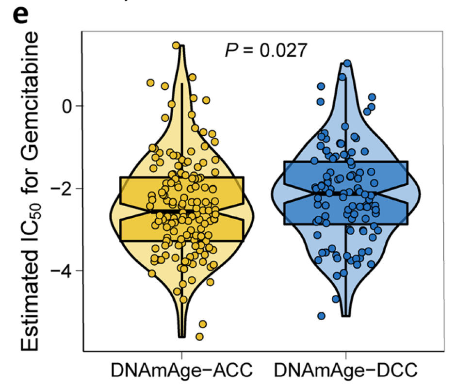

出自https://clinicalepigeneticsjournal.biomedcentral.com/articles/10.1186/s13148-020-0822-y From https://clinicalepigeneticsjournal.biomedcentral.com/articles/10.1186/s13148-020-0822-y

Fig. 1 Correlations between DNAm age and chronological age and other molecular characteristics of DNAm age groups. c DNAmAge-ACC group presented with significantly higher HPVpca scores than DNAmAge-DEC group and was inferred to be much more sensitive to two commonly used chemotherapy drugs, i.e. paclitaxel and gemcitabine, as shown in (d) and (e), respectively. The test for association between paired samples used Pearson’s correlation coefficient. Two-tailed statistical P values were calculated by a two-sample Mann-Whitney test or Student’s t test when appropriate

# 应用场景

# Application Scenarios

对比两组或多组数据，原始数据、统计量（boxplot）、统计推断（violin plot, 概率密度）画一起。 Compare two or more sets of data, plotting the original data, statistics (boxplot), and statistical inferences (violin plot, probability density) together.

类似于FigureYa68friends，一半violin、box、一半原始数据。 Similar to FigureYa68friends, half is violin, box, and half is original data.

为什么这样画？原理可参考这篇https://mp.weixin.qq.com/s/kd-WbPXPrg6K2RFNydK-mQ。 Why draw this way? For the principle, please refer to this article https://mp.weixin.qq.com/s/kd-WbPXPrg6K2RFNydK-mQ

# 环境设置

# Environment Setup

```r
source("install_dependencies.R")
```

```
## Starting R package installation...
## ===========================================
##
## Installing CRAN packages...
## Package already installed: ggplot2
## Package already installed: ggpubr
##
## ===========================================
## Package installation completed!
## You can now run your R scripts in this directory.
```

Load the package

```r
library(ggplot2)
library(ggpubr)

Sys.setenv(LANGUAGE = "en") #显示英文报错信息 # Display English error messages
options(stringsAsFactors = FALSE) #禁止chr转成factor # Disable conversion of chr to factor
```

# 两组比较，原图复现

# Comparison of two groups, reproducing the original image

## 输入文件

## Input file

```r
tmp <- read.csv("easy_input.csv", row.names = NULL, check.names = F, header = T, stringsAsFactors = F)
head(tmp)
```

```
##    est.ic50     DNAmAge
## 1 -3.449801 DNAmAge-ACC
## 2 -1.840905 DNAmAge-DCC
## 3 -3.040064 DNAmAge-ACC
## 4 -3.454262 DNAmAge-DCC
## 5 -2.741668 DNAmAge-ACC
## 6 -2.937070 DNAmAge-ACC
```

```r
table(tmp$DNAmAge)
```

```
##
## DNAmAge-ACC DNAmAge-DCC
##         148         104
```

## 非参检验

## Nonparametric test

```r
p <- wilcox.test(tmp[which(tmp$DNAmAge == "DNAmAge-ACC"),"est.ic50"],tmp[which(tmp$DNAmAge == "DNAmAge-DCC"),"est.ic50"])$p.value
```

## 开始画图

## Start plotting

用ggplot2画图 Plotting with ggplot2

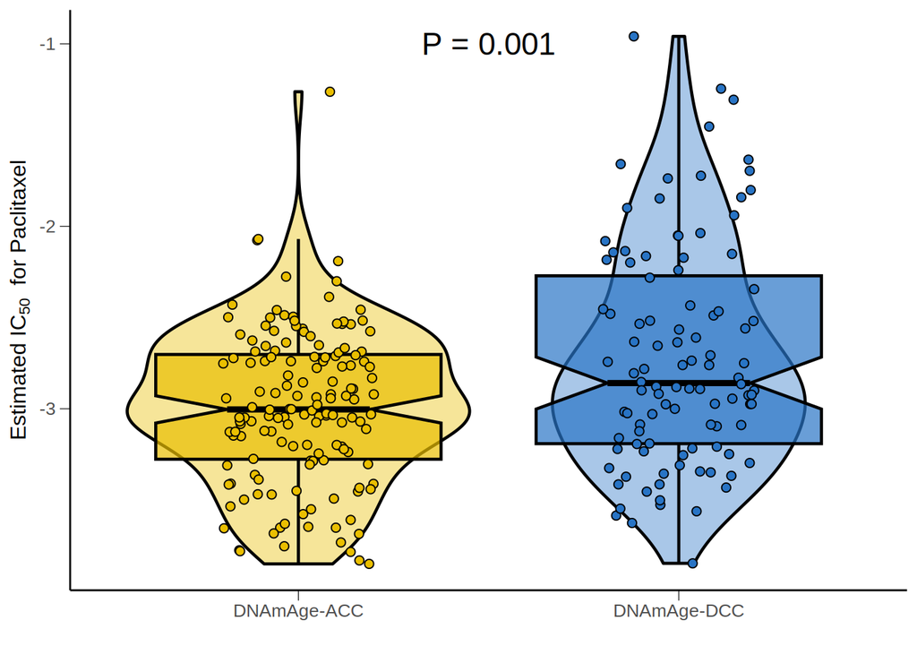

```r
# 设置颜色
# Set colors
jco <- c("#2874C5","#EABF00")

ggplot(data = tmp,aes(x = DNAmAge, y = est.ic50, fill = DNAmAge))+
  scale_fill_manual(values = jco[2:1]) +
  geom_violin(alpha=0.4, position = position_dodge(width = .75),
              size=0.8, color="black") + # 边框线黑色 # border line black
  geom_boxplot(notch = TRUE, outlier.size = -1,
               color="black", lwd=0.8, alpha = 0.7)+ # 背景色透明化 # background color transparent
  geom_point(shape = 21, size=2,
             position = position_jitterdodge(),
             color="black", alpha=1)+ # 边框线黑色 # border line black
  theme_classic() +
  ylab(expression("Estimated IC"[50]~" for Paclitaxel")) +
  xlab("")  +
  annotate(geom="text", cex=6,
           x=1.5, y=-1, # 根据自己的数据调节p value的位置 # Adjust the position of the p value based on your own data
           label=paste0("P ", ifelse(p<0.001, "< 0.001", paste0("= ",round(p,3)))), # 添加P值 # Add the P value
           color="black") +
  theme(#panel.border = element_rect(colour = "black", fill=NA, size=0.2), # 原图有框 # The original image has a frame
        axis.ticks = element_line(size=0.2,color="black"),
        axis.ticks.length = unit(0.2,"cm"),
        legend.position = "none",
        axis.title = element_text(size = 12),
        axis.text = element_text(size = 10))
```

```r
# 保存图像 # Save the image
ggsave("boxViolin.pdf", width = 4.5, height = 4)
```

# 多组比较 # Multiple group comparisons

## 输入文件 ## Input file

```r
tmp <- read.csv("easy_input_multi.csv", row.names = NULL, check.names = F, header = T, stringsAsFactors = F)
head(tmp)
```

```
##   Enrichscore TGFBcluster
## 1   0.1261347   Pink-TGFB
## 2   0.3522893   Pink-TGFB
## 3   0.1158100   Pink-TGFB
## 4   0.1678759   Pink-TGFB
## 5   0.2079235   Pink-TGFB
## 6   0.2611214   Pink-TGFB
```

```r
table(tmp$TGFBcluster)
```

```
##
## Blue-TGFB Grey-TGFB Pink-TGFB  Red-TGFB
##        19        59        87        28
```

## 组间对比及画图

## Intergroup comparison and plotting

用ggpubr的stat_compare_means做kruskal.test Use ggpubr’s stat_compare_means to perform the kruskal.test

用ggplot2画图 Use ggplot2 to plot

```
## Notch went outside hinges
## ℹ Do you want `notch = FALSE`?
```

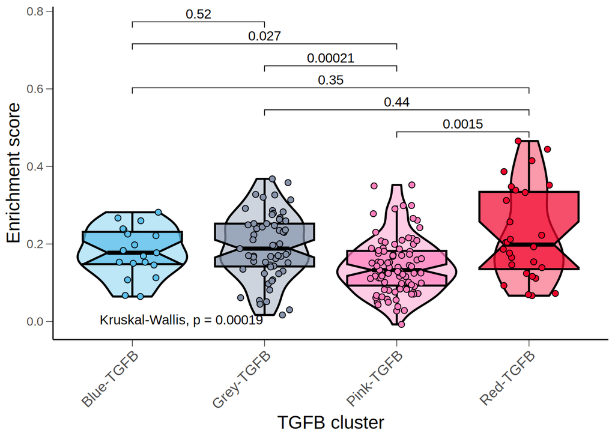

```r
# 设置组间对比，排列组合
# Set up intergroup comparisons and permutations
my_comparisons <- list( c("Red-TGFB", "Pink-TGFB"),
                        c("Red-TGFB", "Grey-TGFB"),
                        c("Red-TGFB", "Blue-TGFB"),
                        c("Pink-TGFB","Grey-TGFB"),
                        c("Pink-TGFB","Blue-TGFB"),
                        c("Grey-TGFB","Blue-TGFB"))

#set color
blue   <- "#5bc0eb"
grey   <- "#8693ab"
darkred   <- "#F2042C"
lightred  <- "#FF7FBF"

ggplot(data = tmp,aes(x = TGFBcluster, #分组列名 #Group column name
                      y = Enrichscore, #连续变量列名 #Continuous variable column name
                      fill = TGFBcluster))+ #按分组填充颜色 #Fill by group
  scale_fill_manual(values = c(blue, grey, lightred, darkred)) + #用自定义颜色填充 #Fill with custom color
  geom_violin(alpha = 0.4, position = position_dodge(width = .75),
              size = 0.8, color="black") +
  geom_boxplot(notch = TRUE, outlier.size = -1,
               color="black", lwd=0.8, alpha = 0.7) +
  geom_point(shape = 21, size=2, # 点的性状和大小 # Point characteristics and size
             position = position_jitterdodge(), # 让点散开 # Spread out the points
             color="black", alpha = 1) +
  theme_classic() +
  ylab("Enrichment score") +
  xlab("TGFB cluster") +
  theme(axis.text.x = element_text(angle = 45, hjust = 1, size = 12),
        #panel.border = element_rect(colour = "black", fill=NA, size=0.2),
        axis.ticks = element_line(size=0.2, color="black"),
        axis.ticks.length = unit(0.2, "cm"),
        legend.position = "none",
        axis.title = element_text(size = 15),
        axis.text = element_text(size = 10)) +

  # 如果不要组间比较就注释掉下面这行
  # Comment out the following line if you don't want between-group comparisons.
  stat_compare_means(comparisons = my_comparisons) +
  stat_compare_means(method = "kruskal.test", label.y = min(tmp$Enrichscore))
```

```r
p
```

```
## [1] 0.001196803
```

```r
ggsave("boxViolin_multipleGroups.pdf", width = 6, height = 6)
```

```
## Notch went outside hinges
## ℹ Do you want `notch = FALSE`?
```